# final

## Feature Selection and Extraction - Fall 2020

## Teacher: Dr. Mahdi Vasighi

## Teaching Assistant: Mrs. Leila Moghaddam

## Student: Reza Khaleghi - 984118

### Importing required packages

```python
import numpy as np
from operator import itemgetter # value comparison based on defined format
from sklearn import preprocessing # encoding labels as numeric values
from sklearn.model_selection import train_test_split # splitting dataset into train and test
from sklearn.neighbors import KNeighborsClassifier # using K-NN classifier as the pattern classifier
from sklearn.metrics import classification_report, confusion_matrix # get the variables for f1-score formula
import progressbar # a library to show the progress and estimate the time
from matplotlib.pylab import plt # to visualize results
```

### Reading the dataset

```python
f = open("Dataset/prostate_preprocessed.txt", "r")
```

```python
data = f.readlines()
```

```python
dataset = []
for i in range(len(data)):
    dataset.append(data[i].split())
dataset = np.matrix(dataset)
```

Because the dataset is already preprocessed, the only required step is to encoding labels

```python
X = np.matrix(dataset[:-1,1:],dtype=np.float64).transpose()
le = preprocessing.LabelEncoder()
y = le.fit_transform((dataset[-1,1:]).transpose())
```

Getting the number of features available for the `Forwad Selection` method.

```python
FEATURES = X.shape[1]
```

### Wrapper

```python
def wrapper(feature_list):
    return SFS(feature_list)
```

variable `log` format: [ (`features selected` + `new candidate feature`), `performance after executing the current state`]

```python
def SFS(feature_list):
    features_selected = []
    log = [] # to record all the results for future information retrival
    bar = progressbar.ProgressBar(max_value=FEATURES) # defining the number of iterations for the progress bar
    # Do until no features left
    while len(feature_list) > 0:
        # run the pattern classifier for current state with prior selected features
        log.append(state_runner(feature_list, features_selected))
        # Find the maximum performance based on current features selected
        feature_list, features_selected = max_finder(feature_list, features_selected, log[-1])
        # update the progress bar
        bar.update(FEATURES - len(feature_list))
    return log
```

```python
def state_runner(feature_list, features_selected):
    log = []
    # as the `feature_list` gets updated, we run the KNN with the previous features selected and new ones
    # also keep all the recored to compare and find the best possible
    for new in feature_list:
        r = pattern_classifier(X[:,(features_selected + [new])],y)
        # store the records in log
        log.append((features_selected + [new], r))
    return log
```

`F1-score` formula: \begin{equation} \textrm{f1-score}=\frac{TP}{TP+\frac{1}{2}(FP+FN)} \end{equation}

### Pattern Classifier

Using K-Nearest Neighbours as our abjective function

```python
def pattern_classifier(X, y):
    # splitting data into train and test
    X_train, X_test, y_train, y_test = train_test_split(X, y, test_size=0.20)
    # using K-NN classifier with 5 neighbours (default recommended K)
    classifier = KNeighborsClassifier(n_neighbors=5)
    # fitting the model
    classifier.fit(X_train, y_train)
    # predicting the test set
    y_pred = classifier.predict(X_test)
    # getting required variables to calculate f1-score
    TN, FP, FN, TP = confusion_matrix(y_test, y_pred).ravel()
    # calculating f1-score
    f1 = TP /(TP + 0.5*(FP+FN))
    return f1
```

```python
def max_finder(feature_list, features_selected, log):
    # comparing performances for each state to find the best state
    maxx = max(log,key=itemgetter(1))[0]
    # remove the feature from the list
    feature_list.remove(maxx[-1])
    # add feature to selected features list
    features_selected.append(maxx[-1])
    # return updated lists
    return feature_list, features_selected
```

Finding the best result

```python
def get_optimal(log):
    maxx = (-1,-1)
    for state in log:
        if max(state,key=itemgetter(1))[1] > maxx[1]:
            maxx = (max(state,key=itemgetter(1))[0], max(state,key=itemgetter(1))[1])
    return maxx
```

Defining the feature numbers to begin the wrapper method

```python
feature_list = list(range(0,FEATURES))
log = wrapper(feature_list)
optimal = get_optimal(log)
optimal
```

```
 99% (2133 of 2135) |################### | Elapsed Time: 2:46:00 ETA:   0:00:00
```

```
([1595, 157, 431], 1.0)
```

```python
mean_level = np.zeros(FEATURES,dtype=np.float64)
for i in range(len(log)):
    c = 0
    sum_ = 0
    for j in log[i]:
        sum_+=j[1]
        c+=1
    mean_level[i] = sum_/c
```

```
0.5473835850512455
```

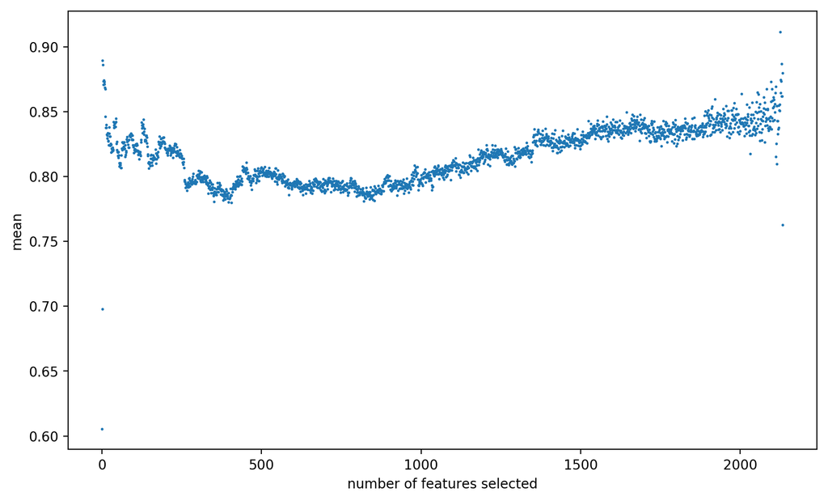

```python
print(mean_level[0])
plt.figure(figsize=(10,6),dpi=200)
plt.scatter(range(len(mean_level[1:])),y=mean_level[1:],s=1)
plt.ylabel("mean")
plt.xlabel("number of features selected")
plt.show()
```

```python
max_count = np.zeros(FEATURES,dtype=np.int16)
for i in range(len(log)):
    c = 0
    for j in log[i]:
        if j[1] == 1.0:
            c+=1
    max_count[i] = c
```

clustering maximum numbers into 20-clusters

```python
summarized = np.zeros(int(FEATURES/20),dtype=np.float64)
su = 0
j = 1
for i in max_count:
    if j % 20 == 0:
        summarized[int(j/20)-1] = su
        su = 0
    else:
        su += i
    j+=1
summarized
```

```
array([1102.,  579.,  585.,  414.,  594.,  403.,  644.,  437.,  413.,
        599.,  501.,  454.,  359.,  163.,  194.,  209.,  148.,  120.,
         87.,  102.,  121.,  184.,  196.,  209.,  186.,  208.,  195.,
        160.,  145.,  124.,  121.,  121.,   98.,  110.,  131.,  106.,
        134.,  111.,  105.,  123.,   71.,   64.,   68.,   69.,   81.,
         86.,  108.,   68.,   86.,  132.,  151.,  105.,  125.,  113.,
        141.,  173.,  119.,  149.,  155.,  177.,  203.,  191.,  192.,
        149.,  151.,  188.,  162.,  225.,  222.,  231.,  214.,  183.,
        199.,  193.,  152.,  185.,  178.,  206.,  201.,  200.,  192.,
        190.,  173.,  186.,  170.,  146.,  159.,  115.,  115.,  134.,
        111.,  113.,  105.,   99.,   90.,   97.,   83.,   83.,   80.,
         69.,   62.,   48.,   42.,   31.,   20.,   13.])
```

```python
plt.figure(figsize=(50,10),dpi=500)
plt.bar(range(len(summarized)),height=summarized)
plt.ylabel("max count")
plt.xlabel("number of features selected in clusters of 20")
plt.savefig("summarized_bar.png")
```

[figure not shown]

**It shows that number of features from 1 to 20 has the most maximum performance between others**

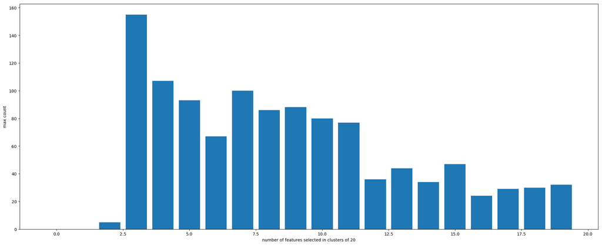

```python
plt.figure(figsize=(25,10),dpi=100)
plt.bar(range(len(max_count[:20])),height=max_count[:20])
plt.ylabel("max count")
plt.xlabel("number of features selected in clusters of 20")
plt.savefig("summarized_bar.png")
```

To neutral the number's effect (decreasing trend) we can divide the result to the number of each set's members

```python
plt.figure(figsize=(50,10),dpi=500)
plt.bar(range(len(max_count)),height=max_count)
plt.ylabel("max weight")
plt.xlabel("number of features selected")
plt.savefig("max_count_bar.png")
```

[figure not shown]

```python
max_count = np.zeros(FEATURES,dtype=np.float64)
for i in range(len(log)):
    c = 0
    for j in log[i]:
        if j[1] == 1.0:
            c+=1
    max_count[i] = c/len(log[i])
```

```python
plt.figure(figsize=(50,10),dpi=500)
plt.scatter(range(len(max_count)),y=max_count,s=30)
plt.ylabel("max weight")
plt.xlabel("number of features selected")
plt.savefig("max_count12.png")
```

[figure not shown]

```python
XX = X[:,optimal[0]]
c = 0
f1=0
while f1 != 1:
    X_train, X_test, y_train, y_test = train_test_split(XX, y, test_size=0.20)
    classifier = KNeighborsClassifier(n_neighbors=5)
    classifier.fit(X_train, y_train)
    y_pred = classifier.predict(X_test)
    TN, FP, FN, TP = confusion_matrix(y_test, y_pred).ravel()
    f1 = TP /(TP + 0.5*(FP+FN))
    c+=1
print(c)
print(confusion_matrix(y_test, y_pred))
print(classification_report(y_test, y_pred).capitalize())
```

```
12
[[ 8  0]
 [ 0 13]]
              precision    recall  f1-score   support

           0       1.00      1.00      1.00         8
           1       1.00      1.00      1.00        13

    accuracy                           1.00        21
   macro avg       1.00      1.00      1.00        21
weighted avg       1.00      1.00      1.00        21
```

```python
c  = 0
f1 = 0
while f1 != 1:
    X_train, X_test, y_train, y_test = train_test_split(X, y, test_size=0.20)
    classifier = KNeighborsClassifier(n_neighbors=5)
    classifier.fit(X_train, y_train)
    y_pred = classifier.predict(X_test)
    TN, FP, FN, TP = confusion_matrix(y_test, y_pred).ravel()
    f1 = TP /(TP + 0.5*(FP+FN))
    c+=1
print(c)
print(confusion_matrix(y_test, y_pred))
print(classification_report(y_test, y_pred).capitalize())
```

```
55
[[13  0]
 [ 0  8]]
              precision    recall  f1-score   support

           0       1.00      1.00      1.00        13
           1       1.00      1.00      1.00         8

    accuracy                           1.00        21
   macro avg       1.00      1.00      1.00        21
weighted avg       1.00      1.00      1.00        21
```

### Every variable's size

```python
import sys
def sizeof_fmt(num, suffix='B'):
    ''' by Fred Cirera,  https://stackoverflow.com/a/1094933/1870254, modified'''
    for unit in ['','Ki','Mi','Gi','Ti','Pi','Ei','Zi']:
        if abs(num) < 1024.0:
            return "%3.1f %s%s" % (num, unit, suffix)
        num /= 1024.0
    return "%.1f %s%s" % (num, 'Yi', suffix)

for name, size in sorted(((name, sys.getsizeof(value)) for name, value in locals().items()),
                         key= lambda x: -x[1])[:10]:
    print("{:>30}: {:>8}".format(name, sizeof_fmt(size)))
```

```
                           log: 18.2 KiB
                          data: 17.3 KiB
                    mean_level: 16.8 KiB
                     max_count: 16.8 KiB
          KNeighborsClassifier:  1.4 KiB
                             y:  912.0 B
                           _i8:  764.0 B
                       y_train:  744.0 B
                           _i1:  645.0 B
                          _i10:  641.0 B
```